# Wątki

W zbiorze danych znajdują się **15594** posty zgrupowane w **3276** wątkach. Średnia liczba postów w wątku wynosi **4.76**, natomiast mediana jest równa **3**.

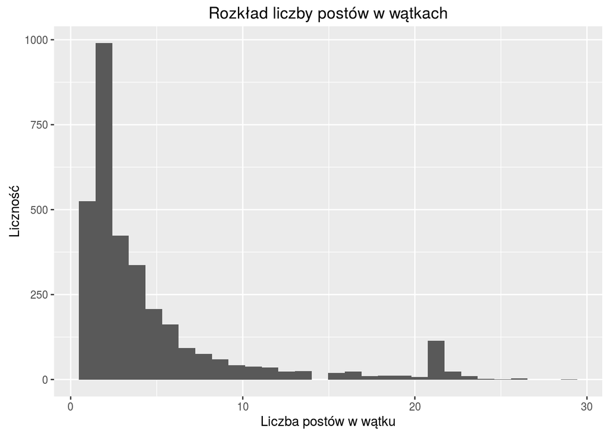

Gdy słowo występuje w większości tekstów, idf będzie małe, dzięki czemu waga dla tego słowa też będzie mała. Natomiast gdy słowo występuje w niewielu tekstach, to idf będzie duże, przez co waga $\mathrm{tfidf}$ również będzie rosła.

Poniżej przedstawiamy dwa wątki z największą liczbą słów kluczowych.

#### id = 221343

- Witam. Mam pewne uwagi, co do waszego serwisu i pomocy technicznej. Mam problem z smsami zawierającymi hasła jednorazowe. Polega on na tym, że te smsy nie dochodzą do mnie. Dzwoniłem do was, konsultanci sprawdzali, niby wszystko jest ok, smsy zostały wysłane, potwierdzenia otrzymane. Dzwoniłem do mojego operatora nju mobile, zostały wyłączone usługi blokowania, ale problem nadal występował. Zgłosiłem to jeszcze raz do operatora, konsultant zgłosił to do działu technicznego. Cała sprawa miała miejsce wczoraj, dzisiaj dostałem odpowiedź od działu technicznego, że żadne smsy z banku nie dotarły do nich i że problem leży po waszej stronie. Kolejny telefon do konsultanta i znowu słyszę, że problem jest po stronie operatora. Powiedziałem, że skoro tak, to żeby bank skontaktował się z moim operatorem i rozwiązał sprawę. Wtedy usłyszałem, że to jest nie możliwe ponieważ ja jestem klientem waszego banku i mojego operatora komórkowego i skoro problem nie leży po Waszej stronie, to żebym się kontaktował z operatorem. Zmarnowałem ponad godzinę czasu na rozmowy telefoniczne i problem nadal występuje. Waszym hasłem reklamowym jest: Wyższa kultura bankowości - jestem ciekaw na czym ona polega skoro w taki sposób traktujecie nowych klientów Waszego banku.
- @Marcin: Bardzo prosimy, abyś zgłosił ten problem za pośrednictwem panelu “Wiadomości” w bankowości internetowej. Zweryfikujemy je i udzielimy Ci indywidualnej odpowiedzi. [Magda]
- Zgłosił problem drogą internetową ? Dzwoniłem kilku krotnie na waszą infolinię, proszę zapytać konsultantów o moją sprawę. Ja nie mam czasu na zgłaszanie po 10 razy tego samego telefonicznie, czy w jaki kolwiek inny sposób. Proszę się skontaktować z Nju Mobile i wspólnie rozwiązać mój problem.
- Stary zmień Bank, ja też kiedyś u nich miałem konto, lecz ten związek nie przetrwał próby czasu:) Generalnie nie polecam.
- Problem rozwiązany. Problem leży po stronie systemu operacyjnego. Teraz doczytałem się w internecie o tym. Przepraszam za zbędne zamieszanie, ale zdezorientowały mnie sprzeczne informacje z banku i operatora.
- Nie wysylaja smsow,bo brakuje im kompetencji w obsludze klienta:)

#### id = 1200716

- Mamy już za sobą ostatnią odsłonę połączenia Meritum Banku z Alior Bankiem. Serdecznie witamy na naszym profilu dotychczasowych fanów Meritum Banku. W tym miejscu będziemy dzielić się z Wami najważniejszymi informacjami dotyczącymi Alior Banku. Tu także będziecie mogli brać udział w konkursach i wygrać atrakcyjne nagrody m.in. bilety na mecze piłkarskiej Reprezentacji Polski oraz bilety do kina. Zapraszamy Was także do dzielenia się opiniami lub komentarzami. Jesteśmy do Waszej dyspozycji :)
- Jsk zmienić konto z gwarancją na konto internetowe
- Weście sie za robote i zrobię raz na zawsze pozadnie ta stronę z bankowością intrenetowa od rana probuje zrobic przelewe a tu sie niewyswietna numer konta tylko napisz wybierz a co mam kurde wybrac jaja Se robicie to pilna sprawa ! A wasze przepraszam za utrudnianie mi niepomaga
- Najlepiej zmienić bank !!! W innych niema problemów z tak blachymi sprawami
- Ja jakos jestem klientka Alior Banku od 2009 roku i nigdy zadnych problemow nie mam…
- Ją jestem klientem od 2 i też nigdy nie mialem
- kijowy bank
- System internetowej bankowości Alior Banku to bardzo intuicyjna aplikacja, poważnie. Z czym konkretnie ma Pani problem odnośnie przelewu?
- Jestem klientka od 6lat nigdy nie mam problemu.Obsługa super miła i zawsze uśmiech na twarzy
- Beznadzieja. Przez to, ze wykupili Meritum mam teraz same problemy i zero pomocy z ich strony. Odradzam!
- Pati Krysiuk, prosimy o informację, w czym możemy Ci pomóc [Justyna]
- Marzena Wałaszek, w przypadku problemów z bankowością internetową prosimy o kontakt z nasza infolinią pod numerem 19 502, nasi konsultanci zweryfikują sprawę i pomogą rozwiązać problem. [Justyna]
- Marzena Wałaszek, w przypadku problemów z bankowością internetową prosimy o kontakt z nasza infolinią pod numerem 19 502, nasi konsultanci zweryfikują sprawę i pomogą rozwiązać problem. [Justyna]
- Kasia Sławińska-Kula, z chęcią odniesiemy się do Twoich konkretnych uwag. [Justyna]
- Mariola Kubacka dziękujemy za opinie!
- Ania Kowalczyk cieszymy się, że spełniamy twoje oczekiwania. [Kuba]
- Piotr Dowgiert dziękujemy za Twoją opinię! :)
- Napisalam w poscie na strone, gdzie ktos obiecal pomoc i dalej nic.
- Ja niestety jestem klientem “przejętym” razem z Meritum. Niestety - zupełnie nie z mojej winy zostałem pozbawiony na ponad tydzień dostępu do bankowości elektronicznej spółki. Przez tydzień zderzałem się z niekompetencją i niedoinformowaniem pracowników infolinii oraz w oddziale. Po wpisie na FB opieka się zmieniła - skontaktował się ze mną kompetentny pracownik infolinii, ale niestety nie pomógł - okazało się, że przywrócenie dostępu wymaga przeprowadzanie procedury analogicznej do zakładania rachunku firmowego, z wizytą w oddziele i w obecności pełnej reprezentacji spółki. Wskazano oddział, gdzie kompetentny pracownik, nie bez drobnych problemów systemowych, nas obsłużył. Niestety - strata wielu godzin cennego czasu (dwie dwugodzinne wizyty w oddziale, dojazd, długie rozmowy z infolinią - w sumie dzień pracy zebrałby się spokojnie) przy tak drobnej sprawie jest chyba przez bank nie do zrekompensowania. Wprawdzie w tym tygodniu usłyszałem kilka razy “przepraszamy”, ale to mało i nie widzę możliwości poprawy złego wrażenia. Pozdrawiam wszystkich zadowolonych.
- Klaudia zmiana Konta z Gwarancją na Konto Internetowe jest możliwa z pomocą konsultanta poprzez nasza infolinię pod numerem 19 502. [Kuba]
- również jestem klientem “przejętym” z meritumbanku i niestety analogicznie jak poprzednik zostałem pozbawiony dostępu do rachunku firmowego, ale to drobiazg z jakim sobie poradziłem, natomiast niezrozumiałym dla mnie jest to, co usłyszałem na infolinii kilkukrotnie, poza ciągłym odsyłaniem od jednych do kolejnych konsultantów, w wyniku niekompetencji i braku wiedzy pracowników, informacja jaką ostatecznie uzyskałem poraziła swoją … dziwnością ….to najdelikatniejsze słowo. Mianowicie dla kont biznesowych produkty biznes pożyczki decyzją wewnątrzbankową nie będą udostępniane w bankowości internetowej klientów, czyli kliencie nie masz mieć pojęcia jakie jest twoje zadłużenie, kiedy jest zapadalność raty, ani tez co ważne w kontach firmowych jaki udział jest raty kapitałowej i odsetkowej. Rozwiązaniem problemu ze strony banku jest podanie mi telefoniczne wysokości tych rat (ciekawe co na to urząd skarbowy jak na telefon zacznę odliczać odsetki) lub tez wystąpienie w oddziale o harmonogram spłat. Dodam, że konsultanci mają taki podgląd, więc jest to tylko kwestią woli banku. Witamy w wyższej kulturze bankowości…. o marnowaniu czasu na wyjaśniania z wyższej kultury nie wspomnę ..